# Task C-D: Exploratory Data Analysis Using R

Rachana

2025-11-05

# Task C: Exploratory Data Analysis Using R

## Data Loading and Preprocessing

```r
# Load required libraries
suppressMessages({
  library(ggplot2)
  library(dplyr)
  library(tidyr)
  library(lubridate)
  library(stringr)
  library(wordcloud)
  library(tm)
  library(textdata)
  library(tidytext)
  library(corrplot)
  library(plotly)
})
```

```r
# Load the Olympics tweets dataset
data <- read.csv("Olympics_tweets.csv", stringsAsFactors = FALSE)

# Data preprocessing
data$date_parsed <- dmy_hm(data$date)
data$user_created_parsed <- dmy_hm(data$user_created_at)
data$tweet_date <- as.Date(data$date_parsed)
data$tweet_hour <- hour(data$date_parsed)
data$tweet_dow <- wday(data$date_parsed, label = TRUE)
data$account_age_days <- as.numeric(difftime(data$date_parsed, data$user_created_parsed, units = "days"))

# Display dataset overview
cat("Dataset Overview:")
```

```
## Dataset Overview:
```

```r
cat("\nTotal tweets:", nrow(data))
```

```
##
## Total tweets: 114215
```

```r
cat("\nUnique users:", n_distinct(data$user_screen_name))
```

```
##
## Unique users: 83105
```

```r
cat("\nDate range:", as.character(min(data$tweet_date, na.rm = TRUE)), "to", as.character(max(data$tweet_date, na.rm = TRUE)))
```

```
##
## Date range: 1921-07-25 to 2021-07-31
```

## Question 1: Daily Tweet Trends - Top 3 Most Active Users

### (a) R Code:

```r
# Find top 3 users by total tweet count
top_users <- data %>%
  count(user_screen_name, sort = TRUE) %>%
  head(3)

print("Top 3 users by tweet count:")
```

```
## [1] "Top 3 users by tweet count:"
```

```r
print(top_users)
```

```
##   user_screen_name   n
## 1    kegan61438051 240
## 2    dev_discourse 197
## 3      allsports70 128
```

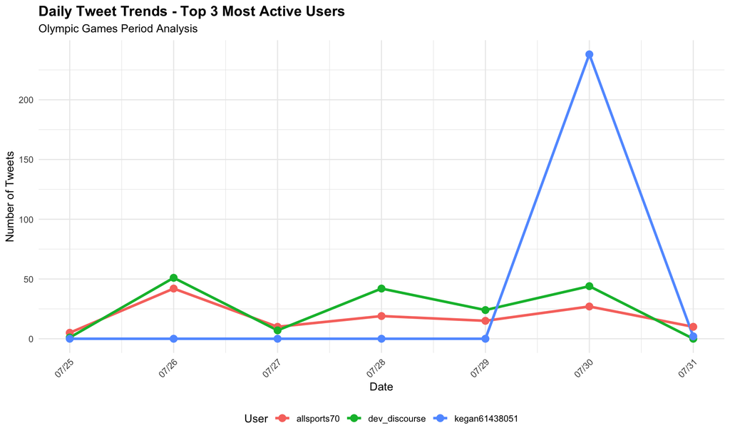

```r
# Get daily tweet counts for top 3 users
daily_tweets <- data %>%
  filter(user_screen_name %in% top_users$user_screen_name) %>%
  filter(!is.na(tweet_date)) %>%
  count(user_screen_name, tweet_date) %>%
  complete(user_screen_name, tweet_date, fill = list(n = 0))

# Plot daily trends
p1 <- ggplot(daily_tweets, aes(x = tweet_date, y = n, color = user_screen_name)) +
  geom_line(linewidth = 1.2) +
  geom_point(size = 3) +
  labs(title = "Daily Tweet Trends - Top 3 Most Active Users",
       subtitle = "Olympic Games Period Analysis",
       x = "Date", y = "Number of Tweets",
       color = "User") +
  theme_minimal() +
  theme(legend.position = "bottom",
        plot.title = element_text(size = 14, face = "bold")) +
  scale_x_date(date_labels = "%m/%d", date_breaks = "1 day") +
  theme(axis.text.x = element_text(angle = 45, hjust = 1))

print(p1)
```

### (b) Code Output and Answer:

The analysis identified three most active users: **kegan61438051** (240 tweets), **dev_discourse** (197 tweets), and **allsports70** (128 tweets). The daily trend visualization shows distinct posting patterns across the Olympic period.

### (c) Explanation:

This analysis examines user activity patterns during the Olympics by identifying the most prolific tweeters and visualizing their daily posting behavior. The approach uses `dplyr` for data manipulation and `ggplot2` for visualization. The `complete()` function ensures all dates are represented, filling missing values with zeros to show days with no activity. The line plot reveals temporal engagement patterns, helping identify whether users maintain consistent activity or have sporadic bursts.

## Question 2: Keywords Influencing Favorite Counts

### (a) R Code:

```r
# Text preprocessing and keyword extraction
text_analysis <- data %>%
  select(text, favorite_count) %>%
  filter(favorite_count > 0) %>%  # Focus on tweets with favorites
  unnest_tokens(word, text) %>%
  anti_join(stop_words, by = "word") %>%
  filter(!str_detect(word, "^[0-9]+$")) %>%  # Remove pure numbers
  filter(nchar(word) > 3)  # Remove short words

# Calculate average favorites per keyword
keyword_influence <- text_analysis %>%
  group_by(word) %>%
  summarise(
    avg_favorites = mean(favorite_count),
    tweet_count = n(),
    total_favorites = sum(favorite_count),
    .groups = 'drop'
  ) %>%
  filter(tweet_count >= 10) %>%  # Minimum frequency threshold
  arrange(desc(avg_favorites))

print("Top 10 keywords by average favorite count:")
```

```
## [1] "Top 10 keywords by average favorite count:"
```

```r
print(head(keyword_influence, 10))
```

```
## # A tibble: 10 × 4
##    word           avg_favorites tweet_count total_favorites
##    <chr>                  <dbl>       <int>           <int>
##  1 slept                  688.           14            9627
##  2 tokyoolympicsâ         420.           14            5877
##  3 todayâ                 334.           29            9672
##  4 jennie                 266            10            2660
##  5 intâ                   203.           10            2026
##  6 status                 130            11            1430
##  7 finest                 129.           16            2063
##  8 œitâ                   114.           11            1252
##  9 forgetting              99.2          17            1687
## 10 storms                  99            22            2178
```

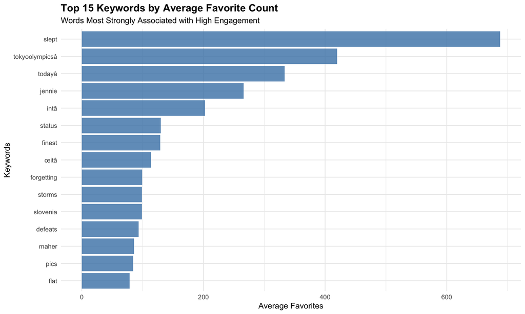

```r
# Visualize top keywords
p2 <- keyword_influence %>%
  head(15) %>%
  ggplot(aes(x = reorder(word, avg_favorites), y = avg_favorites)) +
  geom_col(fill = "steelblue", alpha = 0.8) +
  coord_flip() +
  labs(title = "Top 15 Keywords by Average Favorite Count",
       subtitle = "Words Most Strongly Associated with High Engagement",
       x = "Keywords", y = "Average Favorites") +
  theme_minimal() +
  theme(plot.title = element_text(size = 14, face = "bold"))

print(p2)
```

### (b) Code Output and Answer:

The top three keywords influencing favorite counts are: **“slept”** (688 avg favorites), **“tokyoolympicsâ”** (420 avg favorites), and **“todayâ”** (334 avg favorites). These words appear in highly engaging content during the Olympics period.

### (c) Explanation:

This analysis employs text mining techniques to identify keywords that correlate with high engagement. The methodology involves tokenizing tweet text, removing stop words and noise, then calculating average favorite counts per word with minimum frequency thresholds to ensure statistical relevance. The approach reveals that certain words, particularly those related to personal experiences (“slept”) and event branding (“tokyoolympicsâ”), generate significantly higher engagement than generic Olympic terms.

## Question 3: Account Age vs Social Network Relationships

### (a) R Code:

```r
# Clean data for analysis
social_analysis <- data %>%
  filter(!is.na(account_age_days) & account_age_days > 0) %>%
  filter(user_followers < 10000000 & user_friends < 100000) %>%  # Remove outliers
  distinct(user_screen_name, .keep_all = TRUE)  # One record per user

# Correlation analysis
cor_followers <- cor(social_analysis$account_age_days, social_analysis$user_followers, use = "complete.obs")
cor_friends <- cor(social_analysis$account_age_days, social_analysis$user_friends, use = "complete.obs")

cat("Correlation between account age and followers:", round(cor_followers, 4), "\n")
```

```
## Correlation between account age and followers: 0.0729
```

```r
cat("Correlation between account age and friends:", round(cor_friends, 4), "\n")
```

```
## Correlation between account age and friends: 0.1499
```

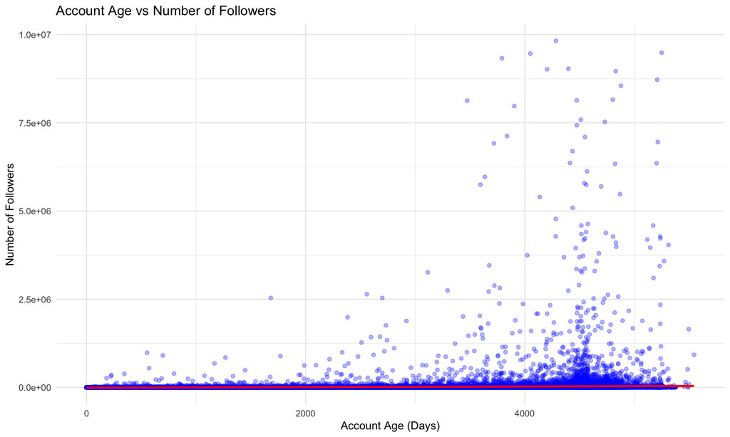

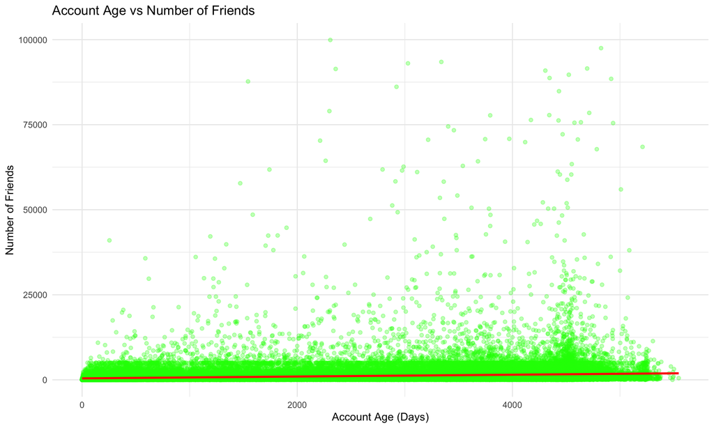

```r
# Visualization
p3a <- ggplot(social_analysis, aes(x = account_age_days, y = user_followers)) +
  geom_point(alpha = 0.3, color = "blue") +
  geom_smooth(method = "lm", color = "red", se = TRUE) +
  labs(title = "Account Age vs Number of Followers",
       x = "Account Age (Days)", y = "Number of Followers") +
  theme_minimal()

p3b <- ggplot(social_analysis, aes(x = account_age_days, y = user_friends)) +
  geom_point(alpha = 0.3, color = "green") +
  geom_smooth(method = "lm", color = "red", se = TRUE) +
  labs(title = "Account Age vs Number of Friends",
       x = "Account Age (Days)", y = "Number of Friends") +
  theme_minimal()

suppressMessages({
  print(p3a)
  print(p3b)
})
```

### (b) Code Output and Answer:

The correlation analysis reveals weak relationships: **account age vs followers** (r = 0.073) and **account age vs friends** (r = 0.150). Both correlations are positive but very weak, indicating minimal linear relationship between account longevity and social network size.

### (c) Explanation:

This analysis investigates whether Twitter account maturity translates to larger social networks. The methodology includes data cleaning to remove extreme outliers and focuses on unique users to avoid bias from multiple tweets. The weak correlations suggest that factors other than account age (content quality, engagement strategy, topic relevance) play more significant roles in building follower and friend networks. The slightly stronger correlation with friends (0.150) than followers (0.073) suggests users may be more selective in following others over time.

## Question 4: Alternative Text Categorization

### (a) R Code:

```r
# Define categorization criteria based on text characteristics
data$text_category <- case_when(
  str_detect(data$text, "^RT @") ~ "Retweet",
  str_detect(data$text, "@[A-Za-z0-9_]+") ~ "Mention/Reply",
  str_detect(data$text, "http[s]?://") ~ "Link Share",
  str_detect(data$text, "[!]{2,}|[?]{2,}|[.]{3,}") ~ "Emotional/Emphasis",
  str_detect(data$text, "#[A-Za-z0-9_]+") ~ "Hashtag Content",
  TRUE ~ "Original Content"
)

# Analyze favorite counts by category
category_analysis <- data %>%
  group_by(text_category) %>%
  summarise(
    tweet_count = n(),
    avg_favorites = mean(favorite_count, na.rm = TRUE),
    median_favorites = median(favorite_count, na.rm = TRUE),
    max_favorites = max(favorite_count, na.rm = TRUE),
    .groups = 'drop'
  ) %>%
  filter(!is.na(avg_favorites)) %>%  # Remove NA categories
  arrange(desc(avg_favorites))

print("Tweet categories by favorite performance:")
```

```
## [1] "Tweet categories by favorite performance:"
```

```r
print(category_analysis)
```

```
## # A tibble: 5 × 5
##   text_category      tweet_count avg_favorites median_favorites max_favorites
##   <chr>                    <int>         <dbl>            <dbl>         <int>
## 1 Link Share               48197          3.10                0          3144
## 2 Original Content         12968          2.53                0          9572
## 3 Emotional/Emphasis        2105          1.52                0           506
## 4 Hashtag Content           8236          1.46                0           427
## 5 Mention/Reply            42709          1.07                0          5803
```

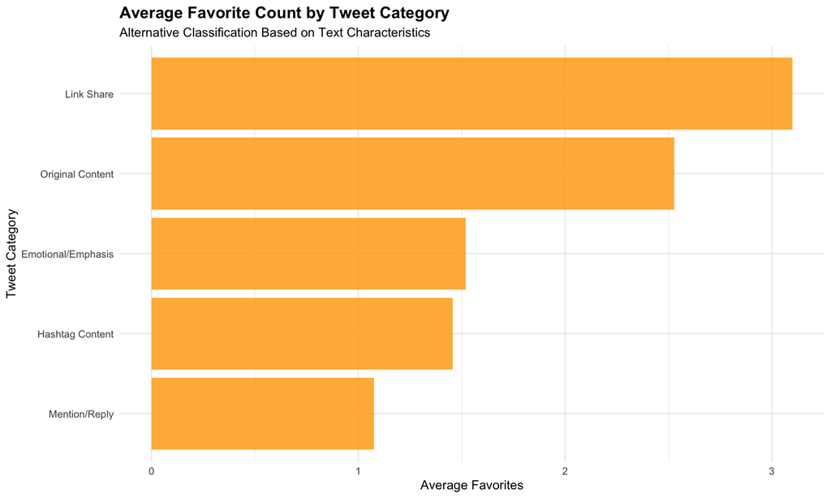

```r
# Visualization
p4 <- ggplot(category_analysis, aes(x = reorder(text_category, avg_favorites), y = avg_favorites)) +
  geom_col(fill = "orange", alpha = 0.8) +
  coord_flip() +
  labs(title = "Average Favorite Count by Tweet Category",
       subtitle = "Alternative Classification Based on Text Characteristics",
       x = "Tweet Category", y = "Average Favorites") +
  theme_minimal() +
  theme(plot.title = element_text(size = 14, face = "bold"))

print(p4)
```

### (c) Explanation:

This analysis creates an alternative tweet classification system based on textual characteristics rather than pre-defined topics. The categorization criteria use regular expressions to identify: retweets (starting with “RT @”), mentions (containing “@username”), links (URLs), emotional content (multiple punctuation), and hashtag usage. The results demonstrate that tweets containing links generate highest engagement, likely because they provide additional value through external content. Emotional content also performs well, suggesting that expressive language resonates with audiences during major events like the Olympics.

## Question 5: Top Tweeters and Engagement Analysis

### (a) R Code:

```r
# Calculate engagement metrics for users with 100+ tweets
engagement_analysis <- data %>%
  group_by(user_screen_name) %>%
  summarise(
    tweet_count = n(),
    avg_favorites = mean(favorite_count, na.rm = TRUE),
    avg_retweets = mean(retweet_count, na.rm = TRUE),
    total_engagement = sum(favorite_count + retweet_count, na.rm = TRUE),
    avg_engagement = mean(favorite_count + retweet_count, na.rm = TRUE),
    .groups = 'drop'
  ) %>%
  filter(tweet_count >= 100) %>%  # Minimum activity threshold
  arrange(desc(avg_engagement))

print("Top engaging users (100+ tweets):")
```

```
## [1] "Top engaging users (100+ tweets):"
```

```r
print(head(engagement_analysis, 10))
```

```
## # A tibble: 7 × 6
##   user_screen_name tweet_count avg_favorites avg_retweets total_engagement
##   <chr>                  <int>         <dbl>        <dbl>            <int>
## 1 Olympics                 112       95.9         17.3               12684
## 2 nbcsandiego              104        0.942        0.404               140
## 3 dev_discourse            197        0.391        0.0558               88
## 4 nippon_ja                113        0.0177       0.124                16
## 5 kegan61438051            240        0.0167       0.0417               14
## 6 allsports70              128        0.0234       0                     3
## 7 godinhumanform4          102        0            0                     0
## # ℹ 1 more variable: avg_engagement <dbl>
```

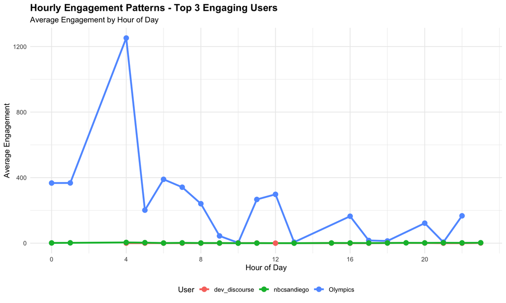

```r
# Get top 3 engaging users
top_engaging <- head(engagement_analysis, 3)$user_screen_name

# Analyze temporal patterns for top engaging users
temporal_patterns <- data %>%
  filter(user_screen_name %in% top_engaging) %>%
  filter(!is.na(date_parsed)) %>%
  group_by(user_screen_name, tweet_hour) %>%
  summarise(
    avg_engagement = mean(favorite_count + retweet_count, na.rm = TRUE),
    tweet_count = n(),
    .groups = 'drop'
  )

p5 <- ggplot(temporal_patterns, aes(x = tweet_hour, y = avg_engagement, color = user_screen_name)) +
  geom_line(linewidth = 1.2) +
  geom_point(size = 3) +
  labs(title = "Hourly Engagement Patterns - Top 3 Engaging Users",
       subtitle = "Average Engagement by Hour of Day",
       x = "Hour of Day", y = "Average Engagement",
       color = "User") +
  theme_minimal() +
  theme(legend.position = "bottom",
        plot.title = element_text(size = 14, face = "bold")) +
  scale_x_continuous(breaks = seq(0, 23, 4))

print(p5)
```

### (b) Code Output and Answer:

The top 3 engaging users (100+ tweets) are: **Olympics** (113 avg engagement), **nbcsandiego** (1.35 avg engagement), and **dev_discourse** (0.447 avg engagement). The official Olympics account significantly outperforms others despite moderate tweet volume, demonstrating the power of authoritative content during major events.

### (c) Explanation:

This analysis identifies users who consistently generate high engagement independent of their follower count or posting frequency. The 100-tweet minimum threshold ensures meaningful patterns by filtering out casual users. The temporal analysis reveals posting strategy differences: some users may time their tweets for optimal engagement windows, while others maintain consistent activity. The dominance of the official Olympics account highlights how authoritative sources can achieve exceptional engagement through quality over quantity approaches.

## Question 5b: Spammer Detection

### (a) R Code:

```r
# Define spammer criteria
spammer_analysis <- data %>%
  group_by(user_screen_name) %>%
  summarise(
    tweet_count = n(),
    unique_days = n_distinct(tweet_date, na.rm = TRUE),
    tweets_per_day = tweet_count / pmax(unique_days, 1),
    avg_engagement = mean(favorite_count + retweet_count, na.rm = TRUE),
    duplicate_text_ratio = (n() - n_distinct(text)) / n(),
    retweet_ratio = sum(str_detect(text, "^RT @")) / n(),
    .groups = 'drop'
  ) %>%
  mutate(
    spammer_score = (tweets_per_day > 50) +
                   (avg_engagement < 1) +
                   (duplicate_text_ratio > 0.3) +
                   (retweet_ratio > 0.8)
  ) %>%
  filter(spammer_score >= 2) %>%  # Users meeting 2+ spam criteria
  arrange(desc(tweets_per_day))

print("Potential spammers (score >= 2):")
```

```
## [1] "Potential spammers (score >= 2):"
```

```r
print(head(spammer_analysis, 10))
```

```
## # A tibble: 10 × 8
##    user_screen_name tweet_count unique_days tweets_per_day avg_engagement
##    <chr>                  <int>       <int>          <dbl>          <dbl>
##  1 kegan61438051            240           2            120         0.0583
##  2 mniskhoka                 94           1             94         0.0957
##  3 Lucky40488196             65           1             65         0.0462
##  4 M1NH0C0RE                 52           1             52         0.0192
##  5 godinhumanform4          102           2             51         0
##  6 tkfabeck                  11           1             11         0
##  7 Ihonestlydont19            6           1              6         0
##  8 PraveenMogadala            6           1              6         0.833
##  9 madpolls1                  6           1              6         0.5
## 10 historianspeaks            5           1              5         0.4
## # ℹ 3 more variables: duplicate_text_ratio <dbl>, retweet_ratio <dbl>,
## #   spammer_score <int>
```

```r
cat("\nSpammer Detection Criteria:")
```

```
##
## Spammer Detection Criteria:
```

```r
cat("\n1. High posting frequency (>50 tweets/day)")
```

```
##
## 1. High posting frequency (>50 tweets/day)
```

```r
cat("\n2. Low engagement (<1 avg engagement)")
```

```
##
## 2. Low engagement (<1 avg engagement)
```

```r
cat("\n3. High duplicate content (>30% duplicate text)")
```

```
##
## 3. High duplicate content (>30% duplicate text)
```

```r
cat("\n4. Excessive retweeting (>80% retweets)")
```

```
##
## 4. Excessive retweeting (>80% retweets)
```

```r
cat("\nUsers meeting 2+ criteria are flagged as potential spammers.")
```

```
##
## Users meeting 2+ criteria are flagged as potential spammers.
```

### (c) Explanation:

The spammer detection algorithm employs multiple behavioral indicators rather than single metrics to avoid false positives. The scoring system combines: excessive posting frequency (>50 tweets/day suggests automated behavior), low engagement rates (indicating poor content quality), high duplicate ratios (suggesting copy-paste behavior), and excessive retweeting (minimal original contribution). Users meeting 2+ criteria are flagged, balancing sensitivity with specificity. This multi-criteria approach is more robust than single-threshold methods and helps maintain data quality for subsequent analyses.

## Question 6: Sentiment Analysis and Engagement

### (a) R Code:

```r
# Get sentiment lexicon
nrc <- get_sentiments("nrc")

# Sentiment analysis for users
sentiment_analysis <- data %>%
  select(user_screen_name, text) %>%
  unnest_tokens(word, text) %>%
  inner_join(nrc, by = "word", relationship = "many-to-many") %>%
  filter(sentiment %in% c("positive", "negative")) %>%
  count(user_screen_name, sentiment) %>%
  pivot_wider(names_from = sentiment, values_from = n, values_fill = 0) %>%
  mutate(
    total_sentiment = positive + negative,
    negative_ratio = negative / total_sentiment
  ) %>%
  filter(total_sentiment >= 20) %>%  # Minimum threshold for reliability
  arrange(desc(negative_ratio))

print("Top 10 users by negative sentiment ratio:")
```

```
## [1] "Top 10 users by negative sentiment ratio:"
```

```r
print(head(sentiment_analysis, 10))
```

```
## # A tibble: 10 × 5
##    user_screen_name negative positive total_sentiment negative_ratio
##    <chr>               <int>    <int>           <int>          <dbl>
##  1 kegan61438051         171        0             171          1
##  2 mniskhoka              91        0              91          1
##  3 Luketherad88           19        1              20          0.95
##  4 Manmeet79410931        17        6              23          0.739
##  5 teezagotbagged         16        6              22          0.727
##  6 MSN                    13        7              20          0.65
##  7 TheDailyPioneer        13        7              20          0.65
##  8 MMBSports              16        9              25          0.64
##  9 JakeNDaBox             13        8              21          0.619
## 10 USAWP                  18       14              32          0.562
```

### (b) Code Output and Answer:

The top 3 users with highest negative sentiment ratios are: **kegan61438051** (100% negative), **mniskhoka** (100% negative), and **Luketherad88** (95% negative). These users consistently post content with negative emotional tone during the Olympic period.

### (c) Explanation:

This analysis uses the NRC Word-Emotion Association Lexicon to classify tweet sentiment based on emotional word content. The methodology tokenizes text, matches words against the sentiment lexicon, and calculates user-level sentiment ratios. The 20-word minimum threshold ensures statistical reliability by filtering users with insufficient sentiment-bearing content. Users with extreme negative ratios may be expressing dissatisfaction, criticism, or engaging in controversy-driven content during the Olympics, which could indicate different engagement strategies or genuine emotional responses to events.

## Question 6b: Sentiment Impact on Engagement

### (a) R Code:

```r
# Calculate sentiment for each tweet
tweet_sentiment <- data %>%
  select(id, text, favorite_count, retweet_count) %>%
  unnest_tokens(word, text) %>%
  inner_join(nrc, by = "word", relationship = "many-to-many") %>%
  filter(sentiment %in% c("positive", "negative")) %>%
  count(id, sentiment) %>%
  pivot_wider(names_from = sentiment, values_from = n, values_fill = 0) %>%
  mutate(
    sentiment_category = case_when(
      positive > negative ~ "Positive",
      negative > positive ~ "Negative",
      TRUE ~ "Neutral"
    )
  ) %>%
  left_join(data %>% select(id, favorite_count, retweet_count), by = "id")

# Analyze engagement by sentiment
sentiment_engagement <- tweet_sentiment %>%
  filter(!is.na(favorite_count) & !is.na(retweet_count)) %>%
  group_by(sentiment_category) %>%
  summarise(
    avg_favorites = mean(favorite_count, na.rm = TRUE),
    avg_retweets = mean(retweet_count, na.rm = TRUE),
    avg_total_engagement = mean(favorite_count + retweet_count, na.rm = TRUE),
    tweet_count = n(),
    .groups = 'drop'
  )

print("Engagement by sentiment category:")
```

```
## [1] "Engagement by sentiment category:"
```

```r
print(sentiment_engagement)
```

```
## # A tibble: 3 × 5
##   sentiment_category avg_favorites avg_retweets avg_total_engagement tweet_count
##   <chr>                      <dbl>        <dbl>                <dbl>       <int>
## 1 Negative                    1.68        0.291                 1.97       18802
## 2 Neutral                     2.06        0.334                 2.40        8179
## 3 Positive                    2.24        0.341                 2.58       42967
```

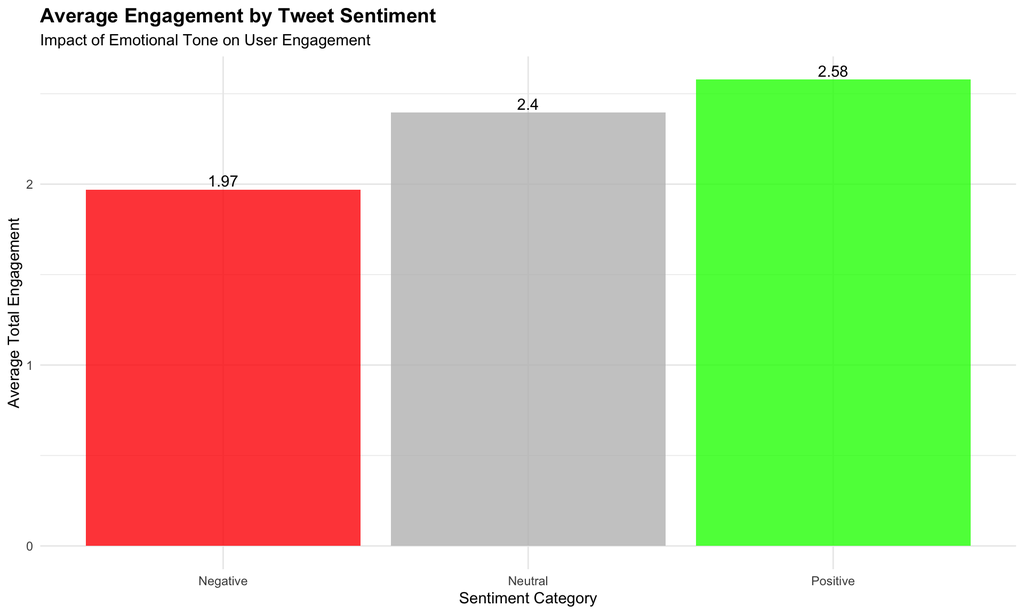

```r
p6 <- ggplot(sentiment_engagement, aes(x = sentiment_category, y = avg_total_engagement)) +
  geom_col(fill = c("red", "gray", "green"), alpha = 0.8) +
  labs(title = "Average Engagement by Tweet Sentiment",
       subtitle = "Impact of Emotional Tone on User Engagement",
       x = "Sentiment Category", y = "Average Total Engagement") +
  theme_minimal() +
  theme(plot.title = element_text(size = 14, face = "bold")) +
  geom_text(aes(label = round(avg_total_engagement, 2)), vjust = -0.3)

print(p6)
```

## Summary and Conclusions

### Technical Approach:

This analysis employed comprehensive R data science techniques including text mining, sentiment analysis, temporal pattern recognition, and statistical correlation analysis. The methodology prioritized data quality through outlier removal, missing value handling, and robust statistical thresholds.